# data_check

2026-08-08

# source

```r
source("preparation.R")
df
```

```
## # A tibble: 885 × 69
##    census_year area_name            area_code entities_total entities_no_land
##    <chr>       <chr>                <chr>              <dbl>            <dbl>
##  1 2010        県計                 000-00             50741              539
##  2 2020        <NA>                 000-00             30005              391
##  3 2010        仙台市               100-00              3110               22
##  4 2015        仙台市               100-00              2273                9
##  5 2020        仙台市               100-00              1641                8
##  6 2010        （原町３－２）       101-01                14                0
##  7 2015        (原町３－２)         101-01                14                0
##  8 2020        青葉区（原町３－２） 101-01                13                0
##  9 2025        青葉区（原町３－２） 101-01                22                0
## 10 2010        生出村２－２         101-02                11                0
## # ℹ 875 more rows
## # ℹ 64 more variables: entities_under_0_3ha <dbl>, entities_0_3_0_5ha <dbl>,
## #   entities_0_5_1_0ha <dbl>, entities_1_0_1_5ha <dbl>,
## #   entities_1_5_2_0ha <dbl>, entities_2_0_3_0ha <dbl>,
## #   entities_3_0_5_0ha <dbl>, entities_5_0_10_0ha <dbl>,
## #   entities_10_0_20_0ha <dbl>, entities_20_0_30_0ha <dbl>,
## #   entities_30_0_50_0ha <dbl>, entities_50_0_100_0ha <dbl>, …
```

# 津波被災関連

QGISで求めた農地面積・被災農地面積と、農水省が公表したそれらの値との乖離程度をチェックする （農水省は旧市区町村単位ではなく市町村単位で公開しているので、まず、QGISで求めた値を市町村単位に直す必要がある）

```r
# まず、旧市区町村×1行のデータにする（2010～2020年の3時点のデータがあると扱いが面倒なので）
gis_farmland_by_city <- df |>
  mutate(
    city_code = substr(area_code, 1, 3)
  ) |>
  distinct(
    city_code,
    area_code,
    farmland_total_by_kcity,
    tunami_farmland_total_by_kcity
  )

# 市町村別に農地面積と被災農地面積を整理したデータフレームをつくる
gis_farmland_by_city <- gis_farmland_by_city |>
  group_by(city_code) |>
  summarise(
    gis_farmland_total =
      sum(farmland_total_by_kcity, na.rm = TRUE),

    gis_tsunami_farmland_total =
      sum(tunami_farmland_total_by_kcity, na.rm = TRUE)
  ) |>
  ungroup()

gis_farmland_by_city <- gis_farmland_by_city |>
  mutate(
    city_code2 = case_when(
      city_code %in% c("101", "102", "103", "104", "105") ~ "100",
      TRUE ~ city_code
    )
  ) |>
  group_by(city_code2) |>
  summarise(
    gis_farmland_total = sum(gis_farmland_total, na.rm = TRUE),
    gis_tsunami_farmland_total = sum(gis_tsunami_farmland_total, na.rm = TRUE),
    .groups = "drop"
  ) |>
  rename(city_code = city_code2)

# 被災市町村についてだけ市町村名列を追加
gis_farmland_by_city <- gis_farmland_by_city |>
  mutate(
    city_name = case_when(
      city_code == "100" ~ "仙台市",
      city_code == "202" ~ "石巻市",
      city_code == "203" ~ "塩竈市",
      city_code == "205" ~ "気仙沼市",
      city_code == "207" ~ "名取市",
      city_code == "209" ~ "多賀城市",
      city_code == "211" ~ "岩沼市",
      city_code == "214" ~ "東松島市",
      city_code == "361" ~ "亘理町",
      city_code == "362" ~ "山元町",
      city_code == "401" ~ "松島町",
      city_code == "404" ~ "七ヶ浜町",
      city_code == "406" ~ "利府町",
      city_code == "581" ~ "女川町",
      city_code == "606" ~ "南三陸町",
      # 以下続ける
      TRUE ~ NA_character_
    )
  )

# 農水省公表の農地面積及び津波被災農地面積
maff_data <- tibble(
  city_name = c(
    "気仙沼市",
    "南三陸町",
    "石巻市",
    "女川町",
    "東松島市",
    "松島町",
    "利府町",
    "塩竈市",
    "多賀城市",
    "七ヶ浜町",
    "仙台市",
    "名取市",
    "岩沼市",
    "亘理町",
    "山元町"
  ),
  # 農水省公式資料記載の各市町村の農地面積
  official_farmland_total = c(
    2220,
    1210,
    10200,
    25,
    3060,
    1030,
    471,
    73,
    365,
    183,
    6580,
    2990,
    1870,
    3450,
    2050
  ),
  # 農水省公式資料記載の各市町村の被災面積
  official_tsunami_farmland = c(
    1032,
    262,
    2107,
    10,
    1495,
    91,
    0,
    27,
    53,
    171,
    2681,
    1561,
    1206,
    2711,
    1595
),
  # 農水省公式資料記載の各市町の畑面積
  official_upland_field_total = c(
    449,
    99,
    97,
    6,
    181,
    2,
    0,
    19,
    0,
    69,
    142,
    194,
    157,
    430,
    472

  )
)

comparison <- gis_farmland_by_city |>
  filter(!is.na(city_name)) |>
  left_join(maff_data, by = "city_name") |>
  mutate(
    # GIS / 農水省
    farmland_ratio =
      gis_farmland_total / official_farmland_total,

    tsunami_farmland_ratio =
      gis_tsunami_farmland_total / official_tsunami_farmland,

    # 面積差
    farmland_diff =
      gis_farmland_total - official_farmland_total,

    tsunami_farmland_diff =
      gis_tsunami_farmland_total - official_tsunami_farmland,

    gis_damage_share =
    gis_tsunami_farmland_total / gis_farmland_total,

    official_damage_share =
    official_tsunami_farmland / official_farmland_total,

    damage_share_diff =
    gis_damage_share - official_damage_share,

    upland_field_ratio =
      official_upland_field_total / official_farmland_total
  )

comparison |> select(city_name, farmland_ratio, tsunami_farmland_ratio, damage_share_diff, upland_field_ratio)
```

```
## # A tibble: 15 × 5
##    city_name farmland_ratio tsunami_farmland_ratio damage_share_diff
##    <chr>              <dbl>                  <dbl>             <dbl>
##  1 仙台市             1.31                   1.01           -0.0935
##  2 石巻市             1.19                   1.43            0.0426
##  3 塩竈市             0.653                  1.32            0.379
##  4 気仙沼市           1.94                   0.872          -0.256
##  5 名取市             1.18                   1.05           -0.0572
##  6 多賀城市           1.13                   1.05           -0.00995
##  7 岩沼市             1.19                   1.17           -0.0121
##  8 東松島市           1.30                   1.24           -0.0214
##  9 亘理町             1.12                   0.898          -0.158
## 10 山元町             1.07                   0.648          -0.306
## 11 松島町             1.24                   1.66            0.0296
## 12 七ヶ浜町           1.02                   1.01           -0.0105
## 13 利府町             1.30                 Inf               0.00166
## 14 女川町             1.97                   1.70           -0.0543
## 15 南三陸町           1.54                   2.06            0.0723
## # ℹ 1 more variable: upland_field_ratio <dbl>
```

全体的に、GISの方が面積を過大評価する傾向がある。これは、圃場データがメッシュなので、実際より面積が膨らんで計算されたためだろう。しかし、中には逆にGISの方が面積を過小評価するパターンもある。そういう地域だと被災面積割合の差が大きくなっている（塩竃、気仙沼、山元町）

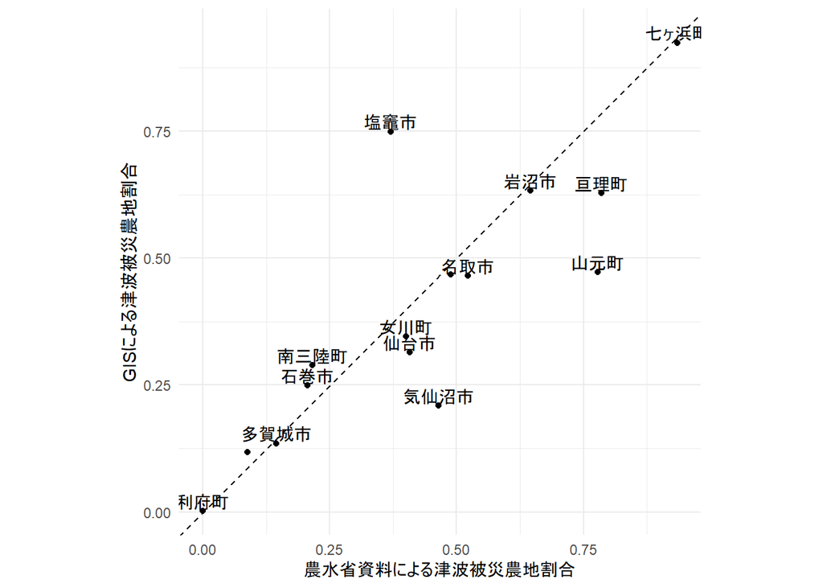

```r
ggplot(
  comparison,
  aes(
    x = official_damage_share,
    y = gis_damage_share,
    label = city_name
  )
) +
  geom_point() +
  geom_text(
    nudge_y = 0.02,
    check_overlap = TRUE
  ) +
  geom_abline(
    intercept = 0,
    slope = 1,
    linetype = "dashed"
  ) +
  coord_equal() +
  labs(
    x = "農水省資料による津波被災農地割合",
    y = "GISによる津波被災農地割合"
  ) +
  theme_minimal()
```

多くの市町村は45度線に近い位置にあるが、気仙沼、塩竃、山元町が大きく外れている。塩竃はGISで被災農地面積割合が過大評価され、山元町、気仙沼では逆に過小評価されている。

```r
comparison |>
  summarise(
    correlation = cor(
      gis_damage_share,
      official_damage_share,
      use = "complete.obs"
    ),
    mae = mean(
      abs(gis_damage_share - official_damage_share),
      na.rm = TRUE
    )
  )
```

```
## # A tibble: 1 × 2
##   correlation   mae
##         <dbl> <dbl>
## 1       0.829 0.100
```

相関係数は非常に高い。平均絶対誤差は0.1程度。

```r
comparison |>
  filter(city_name %in% c("気仙沼市", "塩竈市", "山元町")) |>
  select(
    city_name,
    gis_farmland_total,
    official_farmland_total,
    farmland_ratio,
    gis_tsunami_farmland_total,
    official_tsunami_farmland,
    tsunami_farmland_ratio,
    gis_damage_share,
    official_damage_share,
    damage_share_diff
  )
```

```
## # A tibble: 3 × 10
##   city_name gis_farmland_total official_farmland_total farmland_ratio
##   <chr>                  <dbl>                   <dbl>          <dbl>
## 1 塩竈市                  47.7                      73          0.653
## 2 気仙沼市              4307.                     2220          1.94
## 3 山元町                2189.                     2050          1.07
## # ℹ 6 more variables: gis_tsunami_farmland_total <dbl>,
## #   official_tsunami_farmland <dbl>, tsunami_farmland_ratio <dbl>,
## #   gis_damage_share <dbl>, official_damage_share <dbl>,
## #   damage_share_diff <dbl>
```

- 塩竈市は、農地面積を過小評価していて、津波被災面積はそれなりに正確に求めている。ただ、いずれも面積規模自体がかなり小さいので、誤差による影響は大きそうだ。
- 気仙沼は、津波被災面積は割と正確に求められているが、農地面積を過大評価している（農水省公表値の2倍近い）。
- 山元町は、農地面積はかなり正確に求めているが、津波被災農地面積を過小評価している（農水省公表値の3分の2くらいしかない）

（もしかしたら、センサスの「畑」区分と圃場データの「その他の農用地」区分で定義にずれがあるのではないだろうか。だとすると、「その他の農用地」の比率が大きい地域ではGISを推計の誤差が生じやすい可能性がある。あるいは農水省公式資料で「畑」の比率が大きい地域でみてみてもいい。検証しよう）

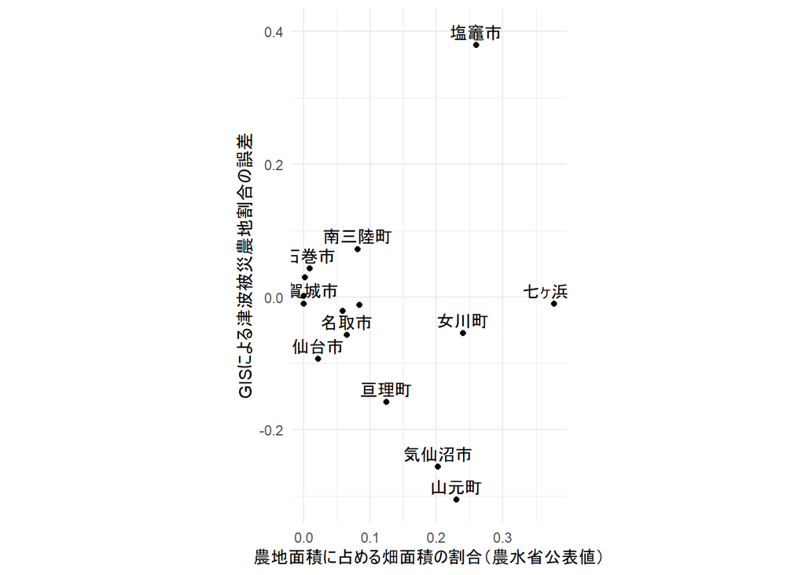

```r
ggplot(
  comparison,
  aes(
    x = upland_field_ratio,
    y = damage_share_diff,
    label = city_name
  )
) +
  geom_point() +
  geom_text(
    nudge_y = 0.02,
    check_overlap = TRUE
  ) +
  coord_equal() +
  labs(
    x = "農地面積に占める畑面積の割合（農水省公表値）",
    y = "GISによる津波被災農地割合の誤差"
  ) +
  theme_minimal()
```

```r
comparison |>
  mutate(
    abs_damage_share_diff = abs(damage_share_diff)
  ) |>
  summarise(
    correlation_abs = cor(
      upland_field_ratio,
      abs_damage_share_diff,
      use = "complete.obs"
    )
  )
```

```
## # A tibble: 1 × 1
##   correlation_abs
##             <dbl>
## 1           0.486
```

```r
# Pearson
cor.test(
  comparison$upland_field_ratio,
  abs(comparison$damage_share_diff)
)
```

```
##
##  Pearson's product-moment correlation
##
## data:  comparison$upland_field_ratio and abs(comparison$damage_share_diff)
## t = 2.007, df = 13, p-value = 0.06601
## alternative hypothesis: true correlation is not equal to 0
## 95 percent confidence interval:
##  -0.03448357  0.79945076
## sample estimates:
##       cor
## 0.4863708
```

```r
# Spearman
cor.test(
  comparison$upland_field_ratio,
  abs(comparison$damage_share_diff),
  method = "spearman",
  exact = FALSE
)
```

```
##
##  Spearman's rank correlation rho
##
## data:  comparison$upland_field_ratio and abs(comparison$damage_share_diff)
## S = 270.74, p-value = 0.04868
## alternative hypothesis: true rho is not equal to 0
## sample estimates:
##       rho
## 0.5165328
```

```r
comparison |>
  filter(!city_name %in% c("塩竈市", "気仙沼市", "山元町")) |>
  summarise(
    correlation_abs = cor(
      upland_field_ratio,
      abs(damage_share_diff),
      use = "complete.obs"
    )
  )
```

```
## # A tibble: 1 × 1
##   correlation_abs
##             <dbl>
## 1          0.0199
```

GIS推計による津波被災農地割合の誤差と農地に占める畑割合との間には、中程度の正の相関がみられた（Pearson r=0.49、Spearman ρ=0.52）。ただし、この関係は推計誤差の大きい塩竈市、気仙沼市、山元町の影響を強く受けており、これら3地域を除くと相関はほぼ消失した。したがって、畑割合は大きな推計誤差が生じる一因である可能性はあるものの、誤差を一般的に説明する単独要因とは考えにくい。

（とはいっても、とりあえず、GIS推計に問題があったというよりも、センサスと圃場データとで「畑」「その他の農業地」のそれぞれの示す範囲が違うことにより引き起こされた誤差であるといえる部分はある。だから、あくまで2009年圃場データに基づく津波浸水農地割合として扱うのなら大きな問題はないだろう。）